# Seaborn Charts using Cars93 Dataset

- Seaborn is a Python data visualization library built on top of Matplotlib.

It provides a high-level interface for creating statistical graphics that are informative, attractive, and easy to interpret.

- Seaborn is specifically designed to work well with Pandas DataFrames and is widely used in Exploratory Data Analysis (EDA) and Data Science projects.

### Why Seaborn is Used (Problem it Solves)

Matplotlib is powerful but:

- Requires more code
- Needs manual styling
- Does not handle statistical plots easily

**Seaborn solves this by:**

- Providing default themes
- Automatically computing statistics (mean, CI, distribution)
- Making EDA faster and cleaner

```python
import pandas as pd
import seaborn as sns
import matplotlib.pyplot as plt
import warnings
warnings.filterwarnings("ignore")

sns.set_theme(style="whitegrid")   #Clean visual styles without extra code

df = pd.read_csv("C:/Users/sagar/Desktop/All Data/Data Sci/csv files/cars93.csv")
df.head()
```

|  | id | Manufacturer | Model | Type | Min.Price | Price | Max.Price | MPG.city | MPG.highway | AirBags | ... | Passengers | Length | Wheelbase | Width | Turn.circle | Rear.seat.room | Luggage.room | Weight | Origin | Make |
| --- | --- | --- | --- | --- | --- | --- | --- | --- | --- | --- | --- | --- | --- | --- | --- | --- | --- | --- | --- | --- | --- |
| 0 | 1 | Acura | Integra | Small | 12.9 | 15.9 | 18.8 | 25 | 31 | NaN | ... | 5 | 177 | 102 | 68 | 37 | 26.5 | 11.0 | 2705 | non-USA | Acura Integra |
| 1 | 2 | Acura | Legend | Midsize | 29.2 | 33.9 | 38.7 | 18 | 25 | Driver & Passenger | ... | 5 | 195 | 115 | 71 | 38 | 30.0 | 15.0 | 3560 | non-USA | Acura Legend |
| 2 | 3 | Audi | 90 | Compact | 25.9 | 29.1 | 32.3 | 20 | 26 | Driver only | ... | 5 | 180 | 102 | 67 | 37 | 28.0 | 14.0 | 3375 | non-USA | Audi 90 |
| 3 | 4 | Audi | 100 | Midsize | 30.8 | 37.7 | 44.6 | 19 | 26 | NaN | ... | 6 | 193 | 106 | 70 | 37 | 31.0 | 17.0 | 3405 | non-USA | Audi 100 |
| 4 | 5 | BMW | 535i | Midsize | 23.7 | 30.0 | 36.2 | 22 | 30 | Driver only | ... | 4 | 186 | 109 | 69 | 39 | 27.0 | 13.0 | 3640 | non-USA | BMW 535i |

5 rows × 28 columns

## 1. Scatter Plot

**Definition:** Shows relationship between two continuous variables.

**Use Case:** Identify correlation, trends, and outliers.

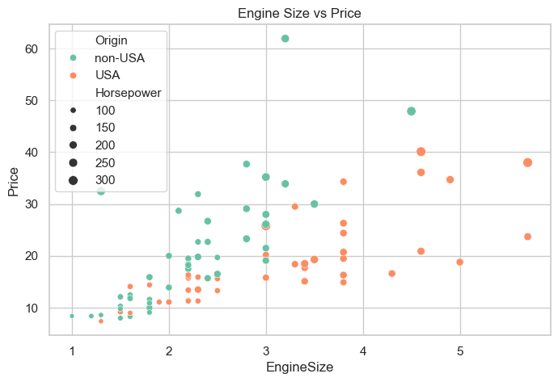

```python
plt.figure(figsize=(8,5))
sns.scatterplot(data=df, x="EngineSize", y="Price", hue="Origin", size="Horsepower", palette="Set2")
plt.title("Engine Size vs Price")
plt.show()
```

## 2. Line Plot

**Definition:** Shows trend over ordered data.

**Use Case:** Trend analysis.

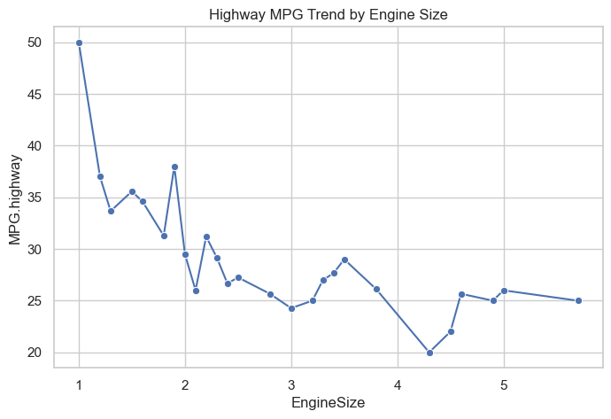

```python
df_sorted = df.sort_values("EngineSize")
plt.figure(figsize=(8,5))
sns.lineplot(data=df_sorted, x="EngineSize", y="MPG.highway", marker="o", ci=None)
plt.title("Highway MPG Trend by Engine Size")
plt.show()
```

## 3. Bar Plot

**Definition:** Shows aggregated statistics.

**Use Case:** Compare categories.

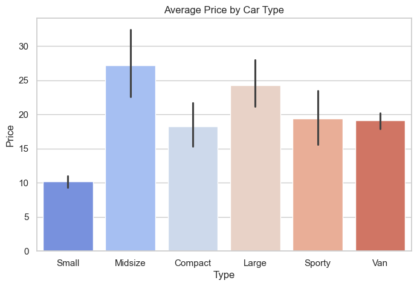

```python
plt.figure(figsize=(8,5))
sns.barplot(data=df, x="Type", y="Price", palette="coolwarm")
plt.title("Average Price by Car Type")
plt.show()
```

## 4. Count Plot

**Definition:** Shows frequency of categories.

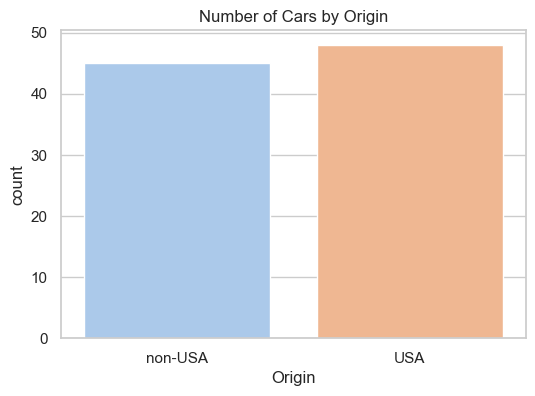

```python
plt.figure(figsize=(6,4))
sns.countplot(data=df, x="Origin", palette="pastel")
plt.title("Number of Cars by Origin")
plt.show()
```

## 5. Histogram

**Definition:** Shows distribution of a numeric variable.

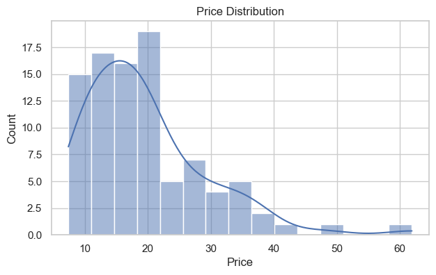

```python
plt.figure(figsize=(7,4))
sns.histplot(df["Price"], bins=15, kde=True)
plt.title("Price Distribution")
plt.show()
```

## 6. Box Plot

**Definition:** Shows quartiles and outliers.

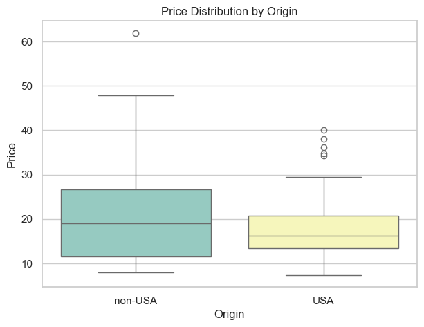

```python
plt.figure(figsize=(7,5))
sns.boxplot(data=df, x="Origin", y="Price", palette="Set3")
plt.title("Price Distribution by Origin")
plt.show()
```

## 7. Violin Plot

**Definition:** Shows distribution shape.

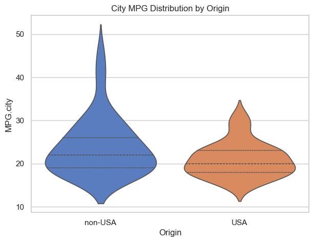

```python
plt.figure(figsize=(7,5))
sns.violinplot(data=df, x="Origin", y="MPG.city", inner="quart", palette="muted")
plt.title("City MPG Distribution by Origin")
plt.show()
```

## 8. Pair Plot

**Definition:** Shows pairwise relationships.

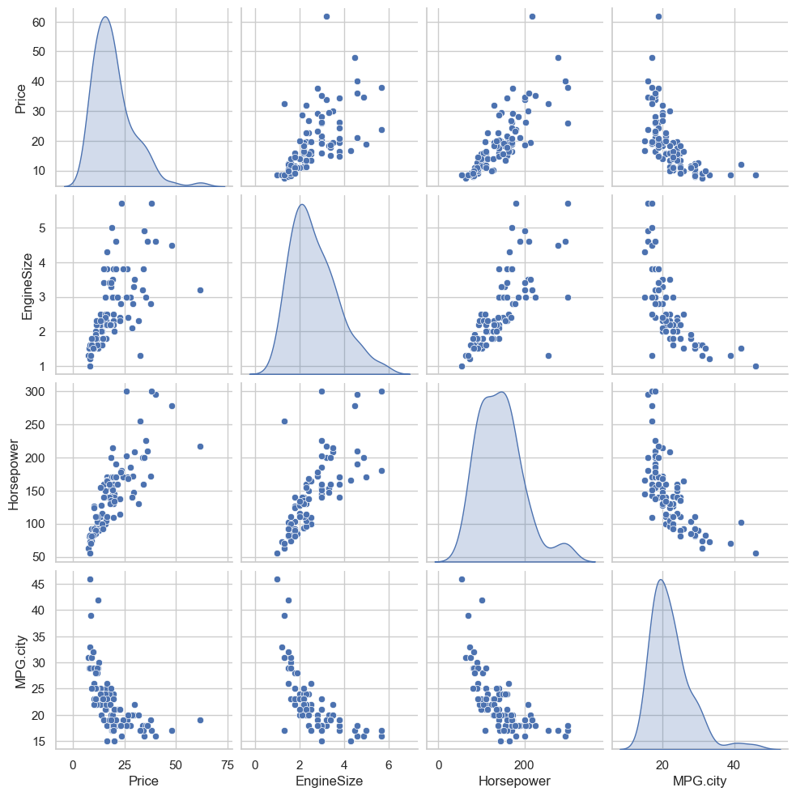

```python
cols = ["Price", "EngineSize", "Horsepower", "MPG.city"]
sns.pairplot(df[cols], diag_kind="kde")
plt.show()
```

## 9. Heatmap

**Definition:** Shows correlation matrix.

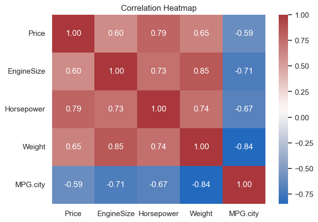

```python
corr = df[["Price", "EngineSize", "Horsepower", "Weight", "MPG.city"]].corr()
plt.figure(figsize=(7,5))
sns.heatmap(corr, annot=True, cmap="vlag", fmt=".2f")
plt.title("Correlation Heatmap")
plt.show()
```

## 10. Regression Plot

**Definition:** Shows linear relationship.

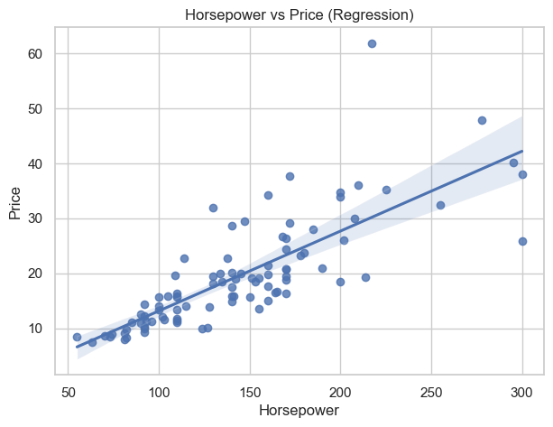

```python
plt.figure(figsize=(7,5))
sns.regplot(data=df, x="Horsepower", y="Price")
plt.title("Horsepower vs Price (Regression)")
plt.show()
```

## 11. relplot

**Definition:** relplot is a figure-level function used to show relationships between numerical variables. It supports both scatter and line plots and allows faceting.

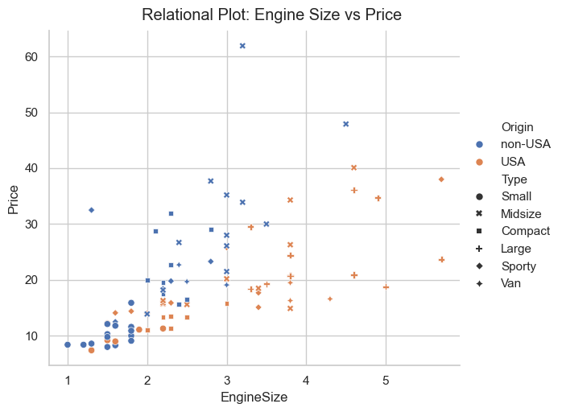

```python
sns.relplot(
    data=df,
    x="EngineSize",
    y="Price",
    hue="Origin",
    style="Type",
    kind="scatter",
    height=5,
    aspect=1.2
)
plt.suptitle("Relational Plot: Engine Size vs Price", y=1.02)
plt.show()
```

## 12. stripplot

**Definition:** stripplot shows individual data points for a categorical variable with optional jitter.

- Small datasets
- Show exact values without aggregation

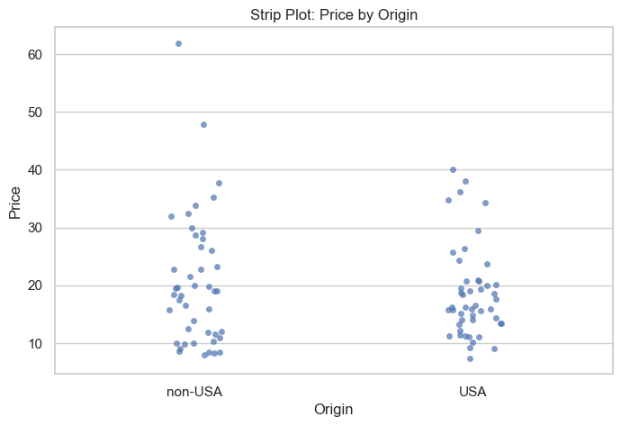

```python
plt.figure(figsize=(8,5))
sns.stripplot(
    data=df,
    x="Origin",
    y="Price",
    jitter=True,
    alpha=0.7
)
plt.title("Strip Plot: Price by Origin")
plt.show()
```

## 13. residplot

**Definition:** residplot displays residuals of a regression model to check model assumptions.

- Validate linear regression
- Detect non-linearity and heteroscedasticity

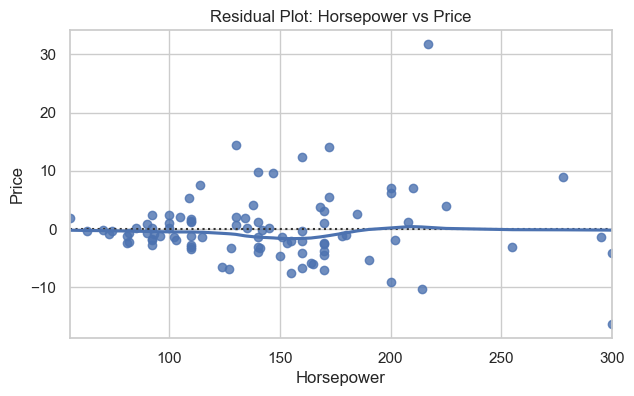

```python
plt.figure(figsize=(7,4))
sns.residplot(
    data=df,
    x="Horsepower",
    y="Price",
    lowess=True
)
plt.title("Residual Plot: Horsepower vs Price")
plt.show()
```

## 14. swarmplot

**Definition:** swarmplot is similar to stripplot but avoids overlapping points.

- Precise distribution visualization for small-to-medium datasets

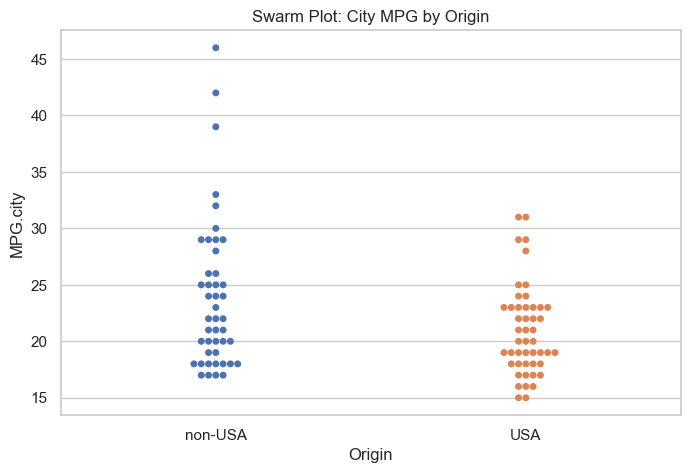

```python
plt.figure(figsize=(8,5))
sns.swarmplot(
    data=df,
    x="Origin",
    y="MPG.city",
    hue="Origin"
)
plt.title("Swarm Plot: City MPG by Origin")
plt.show()
```

## 15. kdeplot

**Definition:** kdeplot shows a smooth probability density curve of a numeric variable.

- Understand distribution shape
- Compare multiple distributions

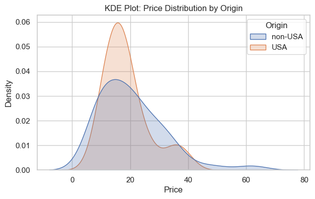

```python
plt.figure(figsize=(7,4))
sns.kdeplot(
    data=df,
    x="Price",
    hue="Origin",
    fill=True,
    common_norm=False
)
plt.title("KDE Plot: Price Distribution by Origin")
plt.show()
```

## 16. displot

**Definition:** displot is a figure-level distribution function that can draw histograms, KDEs, or ECDFs.

- Distribution analysis with faceting

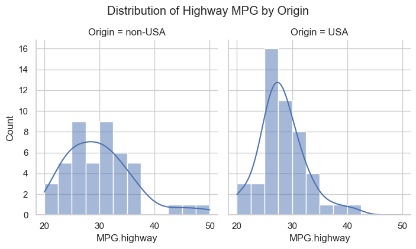

```python
sns.displot(
    data=df,
    x="MPG.highway",
    col="Origin",
    kde=True,
    bins=12,
    height=4,
    aspect=0.9
)
plt.suptitle("Distribution of Highway MPG by Origin", y=1.05)
plt.show()
```

## 17.rugplot

**Definition:** rugplot displays small ticks for each observation along an axis.

- Show raw data density
- Often used with KDE

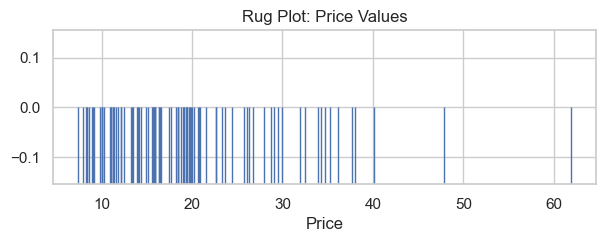

```python
plt.figure(figsize=(7,2))
sns.rugplot(
    data=df,
    x="Price",
    height=0.5
)
plt.title("Rug Plot: Price Values")
plt.show()
```

## 18. regplot (Regression Plot)

**Definition:** regplot shows scatter data + regression line with confidence interval..

- Relationship validation
- Linear trend analysis

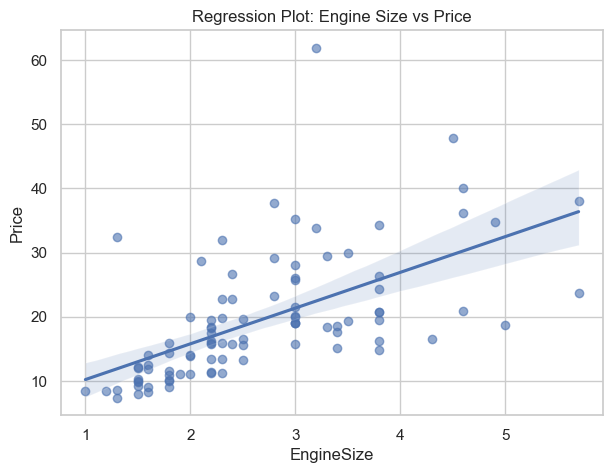

```python
plt.figure(figsize=(7,5))
sns.regplot(
    data=df,
    x="EngineSize",
    y="Price",
    scatter_kws={"alpha":0.6}
)
plt.title("Regression Plot: Engine Size vs Price")
plt.show()
```

## 19.catplot (Categorical Plot)

**Definition:** catplot is a figure-level categorical plotting function supporting multiple plot types.

- Faceted categorical analysis

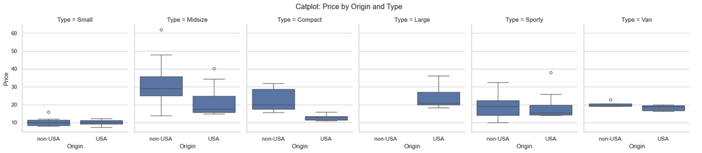

```python
sns.catplot(
    data=df,
    x="Origin",
    y="Price",
    kind="box",
    col="Type",
    height=4,
    aspect=0.8
)
plt.suptitle("Catplot: Price by Origin and Type", y=1.05)
plt.show()
```

## 20. lmplot (Regression + Facet))

**Definition:** lmplot combines regression plot with faceting.

- Compare regression trends across categories

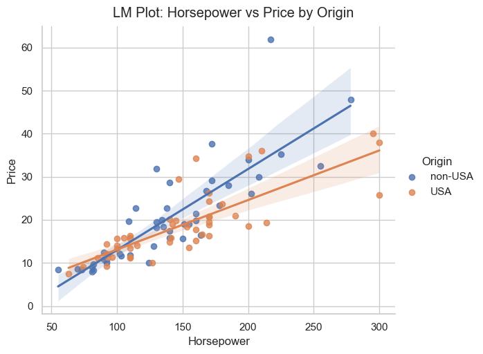

```python
sns.lmplot(
    data=df,
    x="Horsepower",
    y="Price",
    hue="Origin",
    height=5,
    aspect=1.2
)
plt.suptitle("LM Plot: Horsepower vs Price by Origin", y=1.02)
plt.show()
```